# IODS course project

I also created a categorical variable of the crime rate in the Boston datasetand dropped the old crime rate variable from the dataset. This is necessary for the clustering we will do later on.

Moreover, I finally divided the dataset to train and test sets. Now 80% of the data belongs to the train set and 20% to the test set.

Now I will fit the Linear Discriminant Analysis to the train data, by using `crime` as a target variable and all other variables as predictors.

```
## Call:
## lda(crime ~ ., data = train)
##
## Prior probabilities of groups:
##       low   med_low  med_high      high
## 0.2475248 0.2376238 0.2475248 0.2673267
##
## Group means:
##                   zn      indus        chas        nox         rm
## low       1.00102522 -0.9048191 -0.11484506 -0.8792553  0.4405609
## med_low  -0.09978273 -0.3096305 -0.10828322 -0.5424925 -0.1088179
## med_high -0.37490209  0.1736093  0.23949396  0.4261817  0.1336796
## high     -0.48724019  1.0169921 -0.05360128  1.0783189 -0.4575422
##                 age        dis        rad        tax     ptratio
## low      -0.8632996  0.8525349 -0.6648943 -0.7427869 -0.41873275
## med_low  -0.2818685  0.2985681 -0.5404292 -0.4523464 -0.03816121
## med_high  0.4361490 -0.3757458 -0.3950046 -0.3086985 -0.39009462
## high      0.8232721 -0.8586789  1.6393984  1.5149640  0.78225547
##               black       lstat         medv
## low       0.3773199 -0.76247253  0.535298245
## med_low   0.3098971 -0.15204624  0.005040754
## med_high  0.0659256 -0.03018644  0.169313477
## high     -0.6719005  0.95278289 -0.704874737
##
## Coefficients of linear discriminants:
##                   LD1          LD2         LD3
## zn       0.0647479787  0.763012214 -0.93514036
## indus    0.0007651644 -0.284260016  0.06861527
## chas    -0.1182281167 -0.023671603 -0.03967638
## nox      0.4068625816 -0.684893222 -1.25870733
## rm      -0.0857420657 -0.067704535 -0.18622631
## age      0.3233112626 -0.442590021 -0.09793313
## dis     -0.0231613620 -0.395609818  0.12604542
## rad      2.9716306691  0.855926086 -0.40574268
## tax      0.0232313545  0.023672278  0.88170654
## ptratio  0.1008037274  0.113110123 -0.15366545
## black   -0.0943264644  0.002298664  0.11015406
## lstat    0.2114673941 -0.109778504  0.37006469
## medv     0.1762177965 -0.277155226 -0.09806397
##
## Proportion of trace:
##    LD1    LD2    LD3
## 0.9446 0.0422 0.0132
```

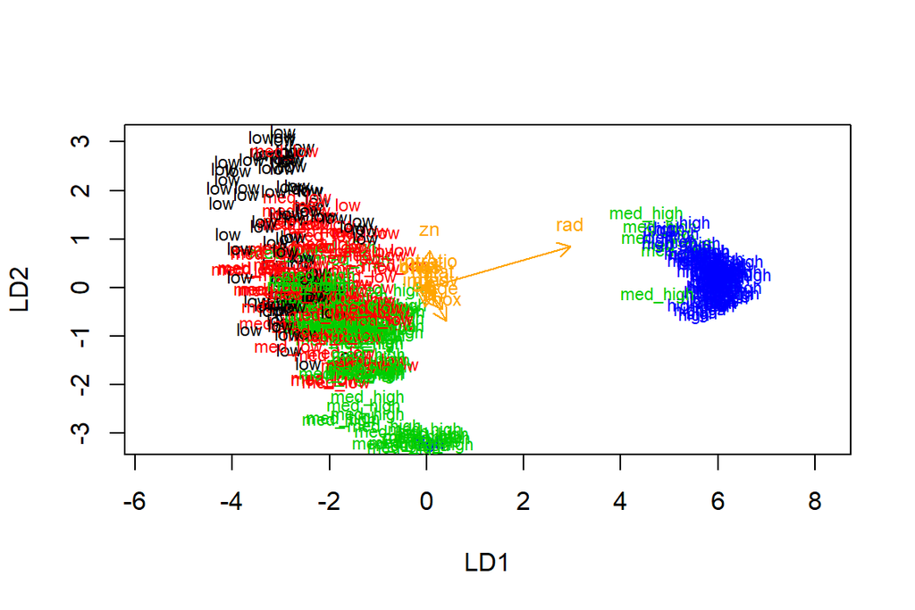

Above you see an LDI biplot with an arrow function. We can interpret from this picture the strenght of specific variables have in clustering the data (and to which direction). For example, `rad` seems to cluster the data into the high-category.

Next I will predict test data with trained model.

```
##           predicted
## correct    low med_low med_high high
##   low       15      11        1    0
##   med_low    8      20        2    0
##   med_high   1       9       16    0
##   high       0       0        0   19
```

It looks like our LDA model is particularly competent in predicting high crime rate (in fact, it gets 19 out of 19 “guesses” correct). This is, for practical purposes, quite good. It does a less good job at predicting med_high and mew_low crime rates, but it’s alright at predicting low crime rates.

Next, I will move on to k-means clustering. Let’s reload the data and standardize it (much like above):

```
##       crim                 zn               indus
##  Min.   :-0.419367   Min.   :-0.48724   Min.   :-1.5563
##  1st Qu.:-0.410563   1st Qu.:-0.48724   1st Qu.:-0.8668
##  Median :-0.390280   Median :-0.48724   Median :-0.2109
##  Mean   : 0.000000   Mean   : 0.00000   Mean   : 0.0000
##  3rd Qu.: 0.007389   3rd Qu.: 0.04872   3rd Qu.: 1.0150
##  Max.   : 9.924110   Max.   : 3.80047   Max.   : 2.4202
##       chas              nox                rm               age
##  Min.   :-0.2723   Min.   :-1.4644   Min.   :-3.8764   Min.   :-2.3331
##  1st Qu.:-0.2723   1st Qu.:-0.9121   1st Qu.:-0.5681   1st Qu.:-0.8366
##  Median :-0.2723   Median :-0.1441   Median :-0.1084   Median : 0.3171
##  Mean   : 0.0000   Mean   : 0.0000   Mean   : 0.0000   Mean   : 0.0000
##  3rd Qu.:-0.2723   3rd Qu.: 0.5981   3rd Qu.: 0.4823   3rd Qu.: 0.9059
##  Max.   : 3.6648   Max.   : 2.7296   Max.   : 3.5515   Max.   : 1.1164
##       dis               rad               tax             ptratio
##  Min.   :-1.2658   Min.   :-0.9819   Min.   :-1.3127   Min.   :-2.7047
##  1st Qu.:-0.8049   1st Qu.:-0.6373   1st Qu.:-0.7668   1st Qu.:-0.4876
##  Median :-0.2790   Median :-0.5225   Median :-0.4642   Median : 0.2746
##  Mean   : 0.0000   Mean   : 0.0000   Mean   : 0.0000   Mean   : 0.0000
##  3rd Qu.: 0.6617   3rd Qu.: 1.6596   3rd Qu.: 1.5294   3rd Qu.: 0.8058
##  Max.   : 3.9566   Max.   : 1.6596   Max.   : 1.7964   Max.   : 1.6372
##      black             lstat              medv
##  Min.   :-3.9033   Min.   :-1.5296   Min.   :-1.9063
##  1st Qu.: 0.2049   1st Qu.:-0.7986   1st Qu.:-0.5989
##  Median : 0.3808   Median :-0.1811   Median :-0.1449
##  Mean   : 0.0000   Mean   : 0.0000   Mean   : 0.0000
##  3rd Qu.: 0.4332   3rd Qu.: 0.6024   3rd Qu.: 0.2683
##  Max.   : 0.4406   Max.   : 3.5453   Max.   : 2.9865
```

```
## [1] "matrix"
```

Now count euclidean and manhattan distances.

```
##    Min. 1st Qu.  Median    Mean 3rd Qu.    Max.
##  0.1343  3.4625  4.8241  4.9111  6.1863 14.3970
```

```
##    Min. 1st Qu.  Median    Mean 3rd Qu.    Max.
##  0.2662  8.4832 12.6090 13.5488 17.7568 48.8618
```

There’s nothing surprising here: manhattan distances seem longer, but the in fact the relations between euclidean and manhattan distances are more or less similar.

Now I’ll do some k-means clustering (with scaled data).

First I’ll run a clustering process with three centers.

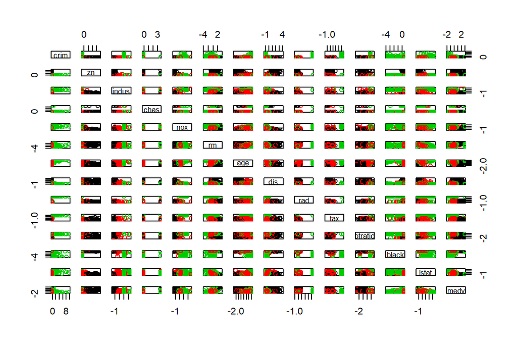

But what I really want to do is find out the optimal number of clusters. So let’s try all numbers of clusters from 1 to 10 and visualise the reslts as an elbow plot. (I use a random seed of 123.)

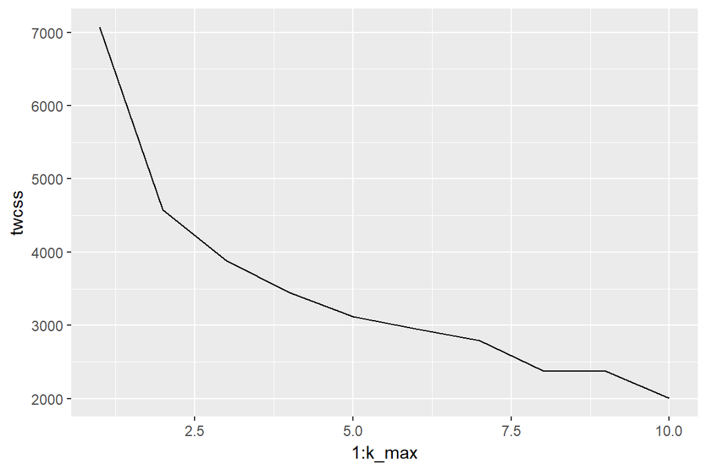

As we notice, the “elbow” of this plot is when k = 2. This is the most efficient way to cluster the data (we are trying to minimize variance as efficiently as possible here; theoretically as k reaches the number of variables, this variance reaches 0).

Therefore, I conclude that the optimal number of centers is two. So finally, I will visualise these clusters.

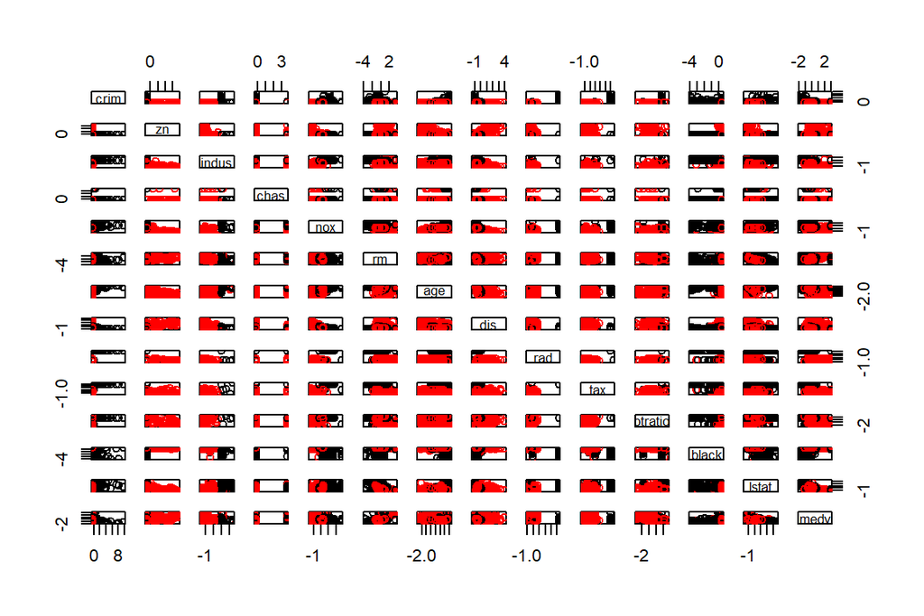

And there you have it. There is a lot (!) to interpret here, but to get to the nitty-gritty: the k-means algorithm seems to do a decent job at clustering. Along the variables, there’s some amount of overlap (e.g. pairs `rm` and `nox`; `dis` and `nox`; etc.). On the other hand, some pairs are very neatly clustered (e.g. `tax` and `crime`; `black` and `zn`). So I think the k-means algorithm is doing a decent job here.

That’s all for this week. Thanks for reading!

## Chapter 5

This week, I will work on dimensionality reduction techniques. I use the ‘human’ dataset, originally from the United Nations Development Programme.

This chapter is preceded by last week’s and this week’s data wrangling, so here’s a quick update on the status of my variables (8 columns, 155 rows):

`FM.Ed` Proportion of females to males with at least secondary education `FM.Lab` Proportion of females o males in the labour force `Life.Exp.` Life expectancy at birth `Exp.Ed` Expected years of schooling `GNI` Gross National Income per capita : `Maternal.Mortality` Maternal mortality ratio `Adol.Birth` Adolescent birth rate `Parliament` Percetange of female representatives in parliament

```
## 'data.frame':    155 obs. of  8 variables:
##  $ FM.Ed             : num  1.007 0.997 0.983 0.989 0.969 ...
##  $ FM.Lab            : num  0.891 0.819 0.825 0.884 0.829 ...
##  $ Life.Exp.         : num  81.6 82.4 83 80.2 81.6 80.9 80.9 79.1 82 81.8 ...
##  $ Exp.Ed            : num  17.5 20.2 15.8 18.7 17.9 16.5 18.6 16.5 15.9 19.2 ...
##  $ GNI               : int  64992 42261 56431 44025 45435 43919 39568 52947 42155 32689 ...
##  $ Maternal.Mortality: int  4 6 6 5 6 7 9 28 11 8 ...
##  $ Adol.Birth        : num  7.8 12.1 1.9 5.1 6.2 3.8 8.2 31 14.5 25.3 ...
##  $ Parliament        : num  39.6 30.5 28.5 38 36.9 36.9 19.9 19.4 28.2 31.4 ...
```

```
## [1] 155   8
```

First let’s present a graphical overview of the data.

I will use ggpairs and corrplot for this again, since the latter in particular is a nice and quick way to get an overview of the relations between the variables.

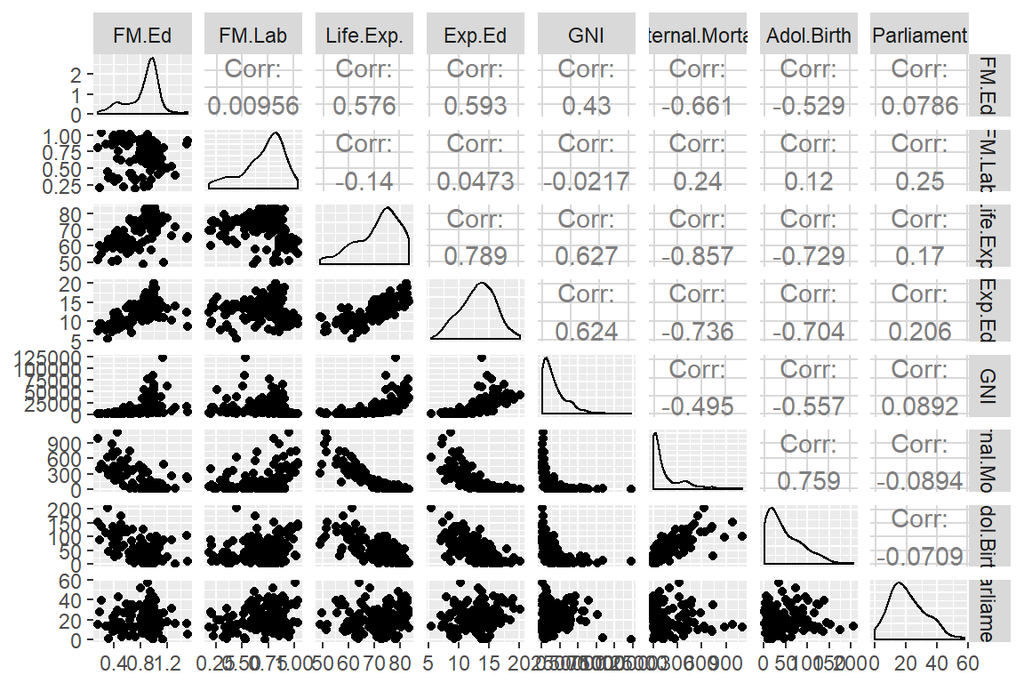

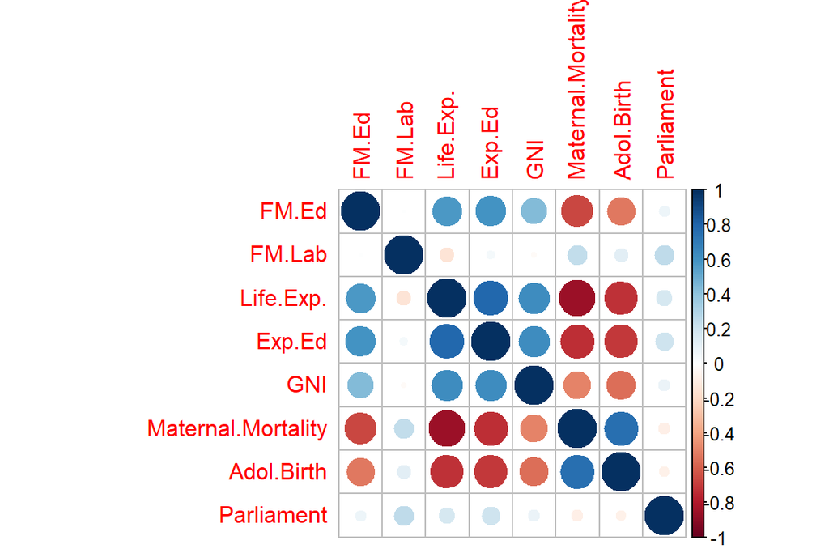

Next, abiding with the instructions, I perform a PCA analysis with non-standardized data. This, of course, makes very little sense, since if some variables have large variances the PCA function will load them more heavily (I presume `GNI` will cause trouble in particular). This is because PCA in fact tries to **maximize the variance** captured by the principal components. So here it is…

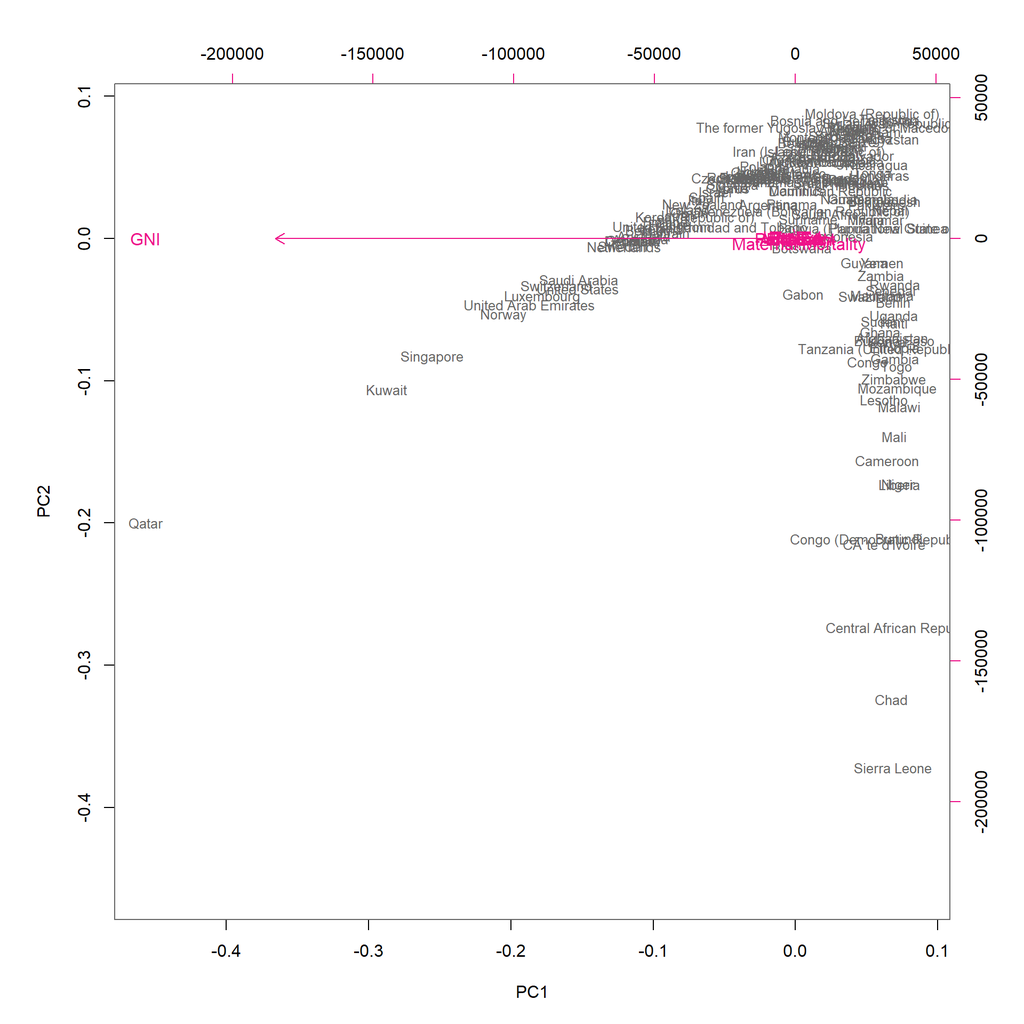

And as we see, the result is a rather ugly and uninformative graph. Ugh! This is because PCA maximises variance, i.e. it projects our data so that it maximizes the variance. Without standardization some particular variables (GNI in particular, as predicted) will form most of the principal component (as it covers the most variance).

So let’s standardize the data instead and produce a new proper PCA analysis:

```
##      FM.Ed             FM.Lab          Life.Exp.           Exp.Ed
##  Min.   :-2.8189   Min.   :-2.6247   Min.   :-2.7188   Min.   :-2.7378
##  1st Qu.:-0.5233   1st Qu.:-0.5484   1st Qu.:-0.6425   1st Qu.:-0.6782
##  Median : 0.3503   Median : 0.2316   Median : 0.3056   Median : 0.1140
##  Mean   : 0.0000   Mean   : 0.0000   Mean   : 0.0000   Mean   : 0.0000
##  3rd Qu.: 0.5958   3rd Qu.: 0.7350   3rd Qu.: 0.6717   3rd Qu.: 0.7126
##  Max.   : 2.6646   Max.   : 1.6632   Max.   : 1.4218   Max.   : 2.4730
##       GNI          Maternal.Mortality   Adol.Birth        Parliament
##  Min.   :-0.9193   Min.   :-0.6992    Min.   :-1.1325   Min.   :-1.8203
##  1st Qu.:-0.7243   1st Qu.:-0.6496    1st Qu.:-0.8394   1st Qu.:-0.7409
##  Median :-0.3013   Median :-0.4726    Median :-0.3298   Median :-0.1403
##  Mean   : 0.0000   Mean   : 0.0000    Mean   : 0.0000   Mean   : 0.0000
##  3rd Qu.: 0.3712   3rd Qu.: 0.1932    3rd Qu.: 0.6030   3rd Qu.: 0.6127
##  Max.   : 5.6890   Max.   : 4.4899    Max.   : 3.8344   Max.   : 3.1850
```

```
## Importance of components:
##                           PC1    PC2     PC3     PC4     PC5     PC6
## Standard deviation     2.0708 1.1397 0.87505 0.77886 0.66196 0.53631
## Proportion of Variance 0.5361 0.1624 0.09571 0.07583 0.05477 0.03595
## Cumulative Proportion  0.5361 0.6984 0.79413 0.86996 0.92473 0.96069
##                            PC7     PC8
## Standard deviation     0.45900 0.32224
## Proportion of Variance 0.02634 0.01298
## Cumulative Proportion  0.98702 1.00000
```

[figure not shown]

With the standardized version, things look different.

Let’s interpret the angles between original variables and the principal components (PC1 and PC2) first.

Let’s analyse PC1 first, which explains around 54 % of total variance: GNI, life expectancy, expected education, proportion of females in education, maternal mortality and adolescent birth rate seem to correlate with PC1. Life expectancy looks like the strongest single predictor here.

With PC2, the ratio of females in parliament and the labor force seem to correlate.

It seems to me like PC1 could be labelled as something like “Health and education” (which increases to the left on the x-axis) whereas PC2 could be labelled “Democracy and gender representation” (which increases upwards on the y-axis). By looking at the countries, they seem to group quite nicely here. We can clearly see the Nordic states, northern central European states and Oceanic states grouped at the top left (highest in both PCA’s, i.e. high health and democracy). On the opposite side of the spectrum, poor and war-torn countries such as Sudan and Afghanistan score lowest on the PCA’s.

This is all quite interesting, actually, since the grouping between the principal components makes good sense.

But enough with the PCA’s. What follows next is some tea analysis to lighten things up a bit.

```
## 'data.frame':    300 obs. of  36 variables:
##  $ breakfast       : Factor w/ 2 levels "breakfast","Not.breakfast": 1 1 2 2 1 2 1 2 1 1 ...
##  $ tea.time        : Factor w/ 2 levels "Not.tea time",..: 1 1 2 1 1 1 2 2 2 1 ...
##  $ evening         : Factor w/ 2 levels "evening","Not.evening": 2 2 1 2 1 2 2 1 2 1 ...
##  $ lunch           : Factor w/ 2 levels "lunch","Not.lunch": 2 2 2 2 2 2 2 2 2 2 ...
##  $ dinner          : Factor w/ 2 levels "dinner","Not.dinner": 2 2 1 1 2 1 2 2 2 2 ...
##  $ always          : Factor w/ 2 levels "always","Not.always": 2 2 2 2 1 2 2 2 2 2 ...
##  $ home            : Factor w/ 2 levels "home","Not.home": 1 1 1 1 1 1 1 1 1 1 ...
##  $ work            : Factor w/ 2 levels "Not.work","work": 1 1 2 1 1 1 1 1 1 1 ...
##  $ tearoom         : Factor w/ 2 levels "Not.tearoom",..: 1 1 1 1 1 1 1 1 1 2 ...
##  $ friends         : Factor w/ 2 levels "friends","Not.friends": 2 2 1 2 2 2 1 2 2 2 ...
##  $ resto           : Factor w/ 2 levels "Not.resto","resto": 1 1 2 1 1 1 1 1 1 1 ...
##  $ pub             : Factor w/ 2 levels "Not.pub","pub": 1 1 1 1 1 1 1 1 1 1 ...
##  $ Tea             : Factor w/ 3 levels "black","Earl Grey",..: 1 1 2 2 2 2 2 1 2 1 ...
##  $ How             : Factor w/ 4 levels "alone","lemon",..: 1 3 1 1 1 1 1 3 3 1 ...
```

[output cut: 22 more lines]

```
## [1] 300  36
```

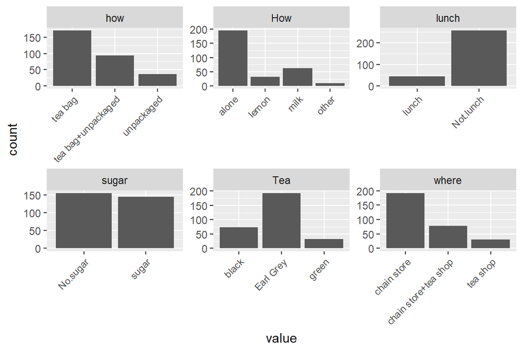

This is interesting: people seem to prefer Earl Grey tea. Well, it’s a classic choice, after all. The respondents also seem torn between sugar and no sugar (I’m a no sugar person myself). Tea shops don’t seem to do too well, which is also unsurprising and truly a shame. And people seem to be convenient teabaggers.

But enough of the tea tests (punny stats joke intended), let’s do a Multiple Correspondence Analysis on the data:

```
##
## Call:
## MCA(X = tea_time, graph = FALSE)
##
##
## Eigenvalues
##                        Dim.1   Dim.2   Dim.3   Dim.4   Dim.5   Dim.6
## Variance               0.279   0.261   0.219   0.189   0.177   0.156
## % of var.             15.238  14.232  11.964  10.333   9.667   8.519
## Cumulative % of var.  15.238  29.471  41.435  51.768  61.434  69.953
##                        Dim.7   Dim.8   Dim.9  Dim.10  Dim.11
## Variance               0.144   0.141   0.117   0.087   0.062
## % of var.              7.841   7.705   6.392   4.724   3.385
## Cumulative % of var.  77.794  85.500  91.891  96.615 100.000
##
## Individuals (the 10 first)
##                       Dim.1    ctr   cos2    Dim.2    ctr   cos2    Dim.3
## 1                  | -0.298  0.106  0.086 | -0.328  0.137  0.105 | -0.327
## 2                  | -0.237  0.067  0.036 | -0.136  0.024  0.012 | -0.695
## 3                  | -0.369  0.162  0.231 | -0.300  0.115  0.153 | -0.202
## 4                  | -0.530  0.335  0.460 | -0.318  0.129  0.166 |  0.211
## 5                  | -0.369  0.162  0.231 | -0.300  0.115  0.153 | -0.202
## 6                  | -0.369  0.162  0.231 | -0.300  0.115  0.153 | -0.202
## 7                  | -0.369  0.162  0.231 | -0.300  0.115  0.153 | -0.202
## 8                  | -0.237  0.067  0.036 | -0.136  0.024  0.012 | -0.695
## 9                  |  0.143  0.024  0.012 |  0.871  0.969  0.435 | -0.067
## 10                 |  0.476  0.271  0.140 |  0.687  0.604  0.291 | -0.650
##                       ctr   cos2
## 1                   0.163  0.104 |
## 2                   0.735  0.314 |
## 3                   0.062  0.069 |
## 4                   0.068  0.073 |
## 5                   0.062  0.069 |
## 6                   0.062  0.069 |
## 7                   0.062  0.069 |
## 8                   0.735  0.314 |
## 9                   0.007  0.003 |
## 10                  0.643  0.261 |
##
## Categories (the 10 first)
```

[output cut: 16 more lines]

```
## lemon                0.035   3.226 |   1.329  14.771   0.218   8.081 |
## milk                 0.020   2.422 |   0.013   0.003   0.000   0.116 |
## other                0.102   5.534 |  -2.524  14.526   0.197  -7.676 |
## tea bag              0.161  -6.941 |  -0.065   0.183   0.006  -1.287 |
## tea bag+unpackaged   0.478  11.956 |   0.019   0.009   0.000   0.226 |
## unpackaged           0.141  -6.482 |   0.257   0.602   0.009   1.640 |
##
## Categorical variables (eta2)
##                      Dim.1 Dim.2 Dim.3
## Tea                | 0.126 0.108 0.410 |
## How                | 0.076 0.190 0.394 |
## how                | 0.708 0.522 0.010 |
## sugar              | 0.065 0.001 0.336 |
## where              | 0.702 0.681 0.055 |
## lunch              | 0.000 0.064 0.111 |
```

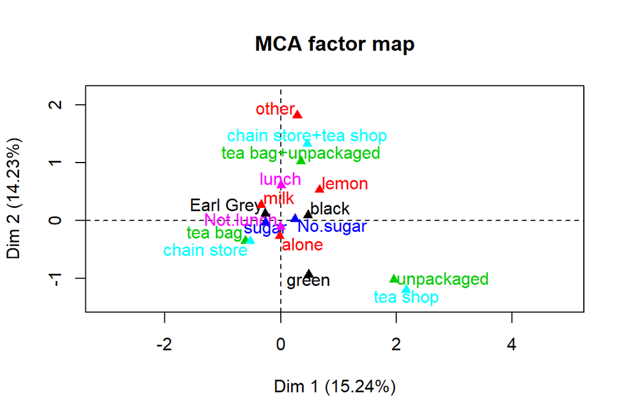

The MCA factor map reduced the data into two dimensions. The first dimension, Dim 1, explains about 15 % of the variance of the data. Dim 2 explains about 14 % of the variance. The first conclusion is therefore that this dimension reduction map isn’t spectacularly good at organizing the data, since it only explains about a third of the total variance of the data. Dim 1 seems particularly to predict where the tea is bought (tea shop or chain store), differenting between “aficionado’s” (tea shop & unpackaged) and more casual drinkers. The second dimension is a lot more complex to intepret. In fact, I find it very difficult to label this factor as it has very little coherence thematically, but that’s something we’ll have to live with. Actually this difficulty to label it makes good sense, since the factor only explains such a small amount of variance to begin with.

That’s all for this week, thank you for reading!

## Chapter 6

Welcome to the final week of IODS! This time, I’ll do some longitudinal data analyses, including graphical displays and linear mixed effects models.

I have completed the data wrangling exercise elsewhere (see the data folder at my GitHub), and I’ll read the resultant data from those into two data frames (I have saved each as a separate .csv file), `RATS` and `BPRS` (note that despite their names here, they are the long forms of the data, or RATSL and BPRSL in the data wrangling exercise). RATS is a data set which describes how rats grow on different diets; BPRS evaluates patients’ scale of schizophrenia over time when subjected to different treatment.

The data are structured as follows:

```
## 'data.frame':    176 obs. of  6 variables:
##  $ X     : int  1 2 3 4 5 6 7 8 9 10 ...
##  $ ID    : int  1 2 3 4 5 6 7 8 9 10 ...
##  $ Group : int  1 1 1 1 1 1 1 1 2 2 ...
##  $ WD    : Factor w/ 11 levels "WD1","WD15","WD22",..: 1 1 1 1 1 1 1 1 1 1 ...
##  $ Weight: int  240 225 245 260 255 260 275 245 410 405 ...
##  $ Time  : int  1 1 1 1 1 1 1 1 1 1 ...
```

```
## 'data.frame':    360 obs. of  6 variables:
##  $ X        : int  1 2 3 4 5 6 7 8 9 10 ...
##  $ treatment: int  1 1 1 1 1 1 1 1 1 1 ...
##  $ subject  : int  1 2 3 4 5 6 7 8 9 10 ...
##  $ weeks    : Factor w/ 9 levels "week0","week1",..: 1 1 1 1 1 1 1 1 1 1 ...
##  $ bprs     : int  42 58 54 55 72 48 71 30 41 57 ...
##  $ week     : int  0 0 0 0 0 0 0 0 0 0 ...
```

```
## [1] 176   6
```

```
## [1] 360   6
```

I begin by plotting the RATS data over time. The groups are separated by diet (`Group`) below.

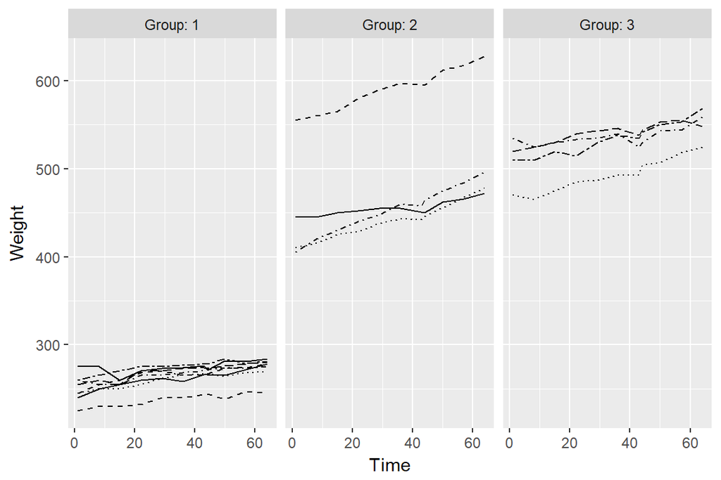

From this graph it particularly seems like Group 1 differs from the others: Their weight starts lower (from the intercept) and continues to track lower than with the other groups. Also noticable already is that the individuals with significantly lower or higher weight at the beginning maintain their relative weight to others (Group 2 has one clear outlier above every other individual, Group 1 and 3 have one individual who drags below the others). This phenomenon is generally called “tracking” in longitudinal data-analysis. Sometimes, standardization of data is used to highlight the tracking effect. Therefore, I will now produce the same graph except with standardized data (Weight - mean(Weight))/sd(Weight)).

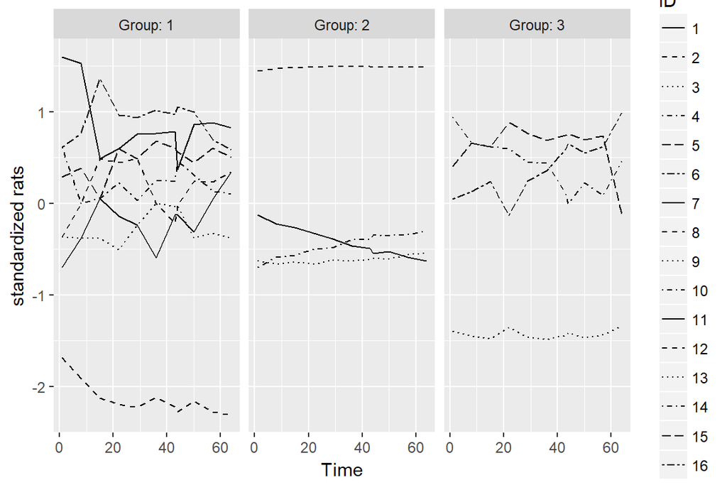

Since standardization centres the data around the a mean (which is 0), in effect we “zoom into” the visualized data. This could help us with identifying tracking phenomena in the data, although in this case I don’t find that the standardization helps us identify any significant new phenomena other than the ones identified above, even if the difference is more clear now.

Next, I will create summary data with which I can plot and run some tests later on. I also create some useful efficients such as the mean and standard error of the data by `Time`.

```
## Observations: 33
## Variables: 4
## $ Group <fct> 1, 1, 1, 1, 1, 1, 1, 1, 1, 1, 1, 2, 2, 2, 2, 2, 2, 2, 2,...
## $ Time  <int> 1, 8, 15, 22, 29, 36, 43, 44, 50, 57, 64, 1, 8, 15, 22, ...
## $ mean  <dbl> 250.625, 255.000, 254.375, 261.875, 264.625, 265.000, 26...
## $ se    <dbl> 4.589478, 3.947710, 3.460116, 4.100800, 3.333956, 3.5529...
```

With the summary data, I can draw this nice plot which displays the mean of each group over time, with the error bars displaying the standard error (or the estimate of standard deviation of its sampling distribution).

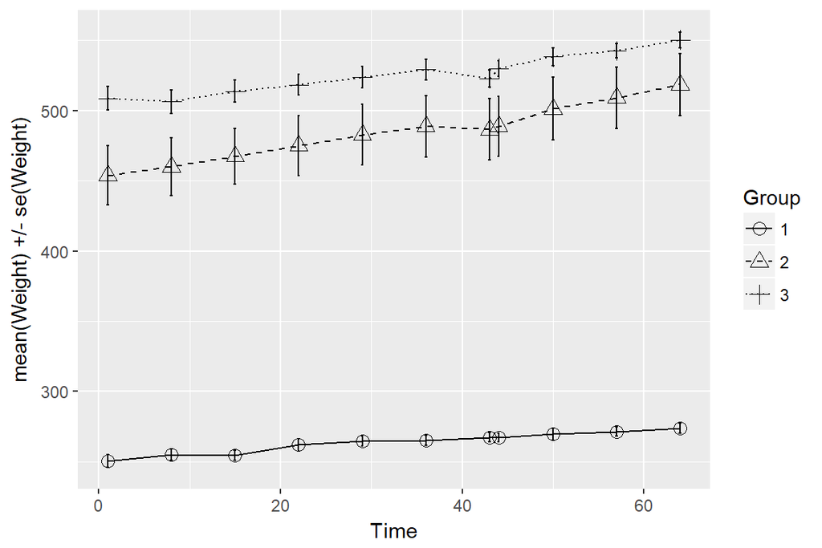

This visualization helps us summarize much of the noisy original data into a more coherent picture. As it seems, the mean line of Group 1 drags considerably below the others, whereas Group 2 has a higher mean over time and Group 3 the highest. The Groups all seem to steadily grow in weight over time (or in other words, if we were to draw a regression line through them, the slope would be more or less the same). Group 1 has the least variance and Group 2 the most.

However, as I pointed out above, we do have some outliers in this data. So let’s spot them and get rid of them. With the summarized data, I’ll now draw two boxplots: one with all the data and one with the most significant outlier removed:

```
## Observations: 16
## Variables: 3
## $ Group <fct> 1, 1, 1, 1, 1, 1, 1, 1, 2, 2, 2, 2, 3, 3, 3, 3
## $ ID    <fct> 1, 2, 3, 4, 5, 6, 7, 8, 9, 10, 11, 12, 13, 14, 15, 16
## $ mean  <dbl> 261.0909, 237.6364, 260.1818, 266.5455, 269.4545, 274.72...
```

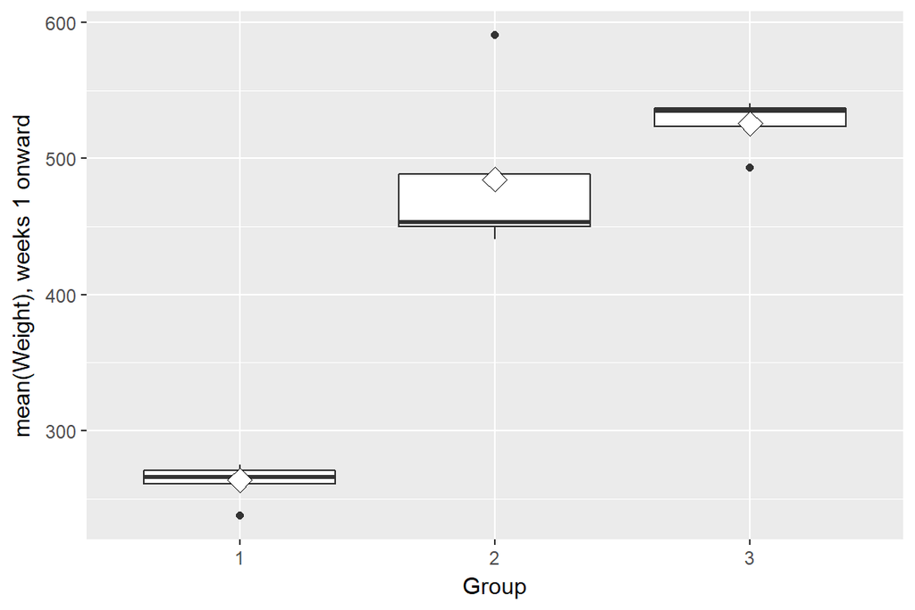

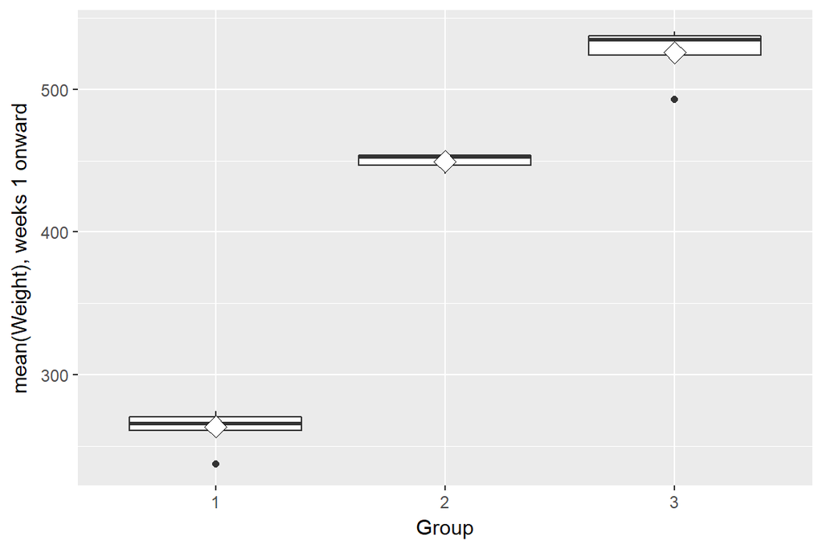

As you’ll notice, the error bars in Group 2 shrink greatly once the outlier is removed. Removing outliers is always a practice one should be cautious with, though, so it is questionable whether we should remove this particular data point or not (to my mind, it doesn’t seem like the data point is a result of any explicit mistake or labeling error; it’s just one heavy rat!).

Finally, since it’s often required to do some explicit statistical analyses (and produce those p-values some people insist on!), let’s run some statistical models. In the datacamp excercies we did a t-test, but with three groups this cannot be done. So I chose to do an ANOVA instead:

```
##             Df Sum Sq Mean Sq F value   Pr(>F)
## Group        2 206390  103195   483.6 3.39e-12 ***
## Residuals   12   2561     213
## ---
## Signif. codes:  0 '***' 0.001 '**' 0.01 '*' 0.05 '.' 0.1 ' ' 1
```

```
## Analysis of Variance Table
##
## Response: mean
##           Df Sum Sq Mean Sq   F value    Pr(>F)
## baseline   1 252125  252125 2237.0655 5.217e-15 ***
## Group      2    726     363    3.2219   0.07586 .
## Residuals 12   1352     113
## ---
## Signif. codes:  0 '***' 0.001 '**' 0.01 '*' 0.05 '.' 0.1 ' ' 1
```

Here’s my interpretation of what’s going on. Firstly, the groups differ significantly between eachother(p = 3.39e-12). This is not really surprising, as we notice from the boxplot above that the groups’ means do in fact differ quite a lot and their confidence intervals do not overlap.

However, when I add the baseline to the data (WD1 from the original RATS data) and fit the linear model `mean ~ baseline + Group` onto the data, it seems like baseline is the strongest predictor of the data points over time. In other words, it seems like the slopes of the Groups do not differ significantly from eachother (p = 0.07586), and the groups just start from a different mean `Weight`. That’s quite interesting, and I’m left wondering about how the case is exactly that the groups differed so largely before the treatment. Hmm…

That’s all for the RATS data, let’s now move on to the BPRS analyses. This will include some relatively complicated linear mixed effect models, possibly the most challenging models in this course so far.

Firstly, a quick look at the structure of the data:

```
## 'data.frame':    360 obs. of  6 variables:
##  $ X        : int  1 2 3 4 5 6 7 8 9 10 ...
##  $ treatment: int  1 1 1 1 1 1 1 1 1 1 ...
##  $ subject  : int  1 2 3 4 5 6 7 8 9 10 ...
##  $ weeks    : Factor w/ 9 levels "week0","week1",..: 1 1 1 1 1 1 1 1 1 1 ...
##  $ bprs     : int  42 58 54 55 72 48 71 30 41 57 ...
##  $ week     : int  0 0 0 0 0 0 0 0 0 0 ...
```

And then, a quick plot of the data (similar to what I did before):

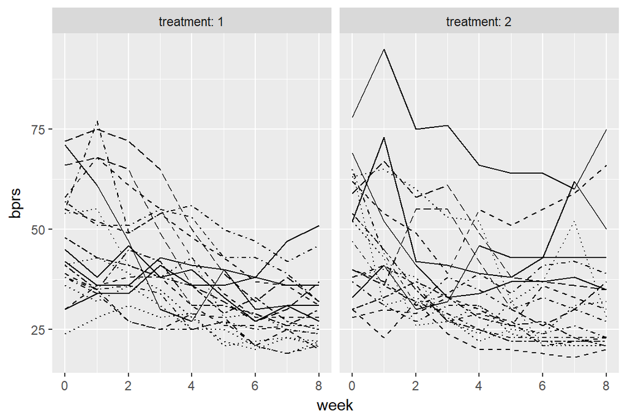

From a face analysis, it seems to me like the two groups (two kinds of treatment) do not differ greatly. You’ll notice some tracking, though, particularly with the highest bprs-scoring individual in treatment 2. Over 8 weeks, the mean scores on bprs seems to lower (either a product of successful treatment or regression towards mediocrity? We won’t know without a control group!). Not much else to report here, so let’s move on to some statistical analyses.

Firstly, I will run a normal regression analysis. Note that in any real analysis this shouldn’t be done, as I am now ignoring the repeated-measures structure of the data and the autocorrelation that goes with it (i.e., the data points are NOT independent of eachother, which is an assumption underlying linear regression models). In any case, here is the multiple regression model with two independent variables (week and treatment).

```
##
## Call:
## lm(formula = bprs ~ week + treatment, data = BPRS)
##
## Residuals:
##     Min      1Q  Median      3Q     Max
## -22.454  -8.965  -3.196   7.002  50.244
##
## Coefficients:
##             Estimate Std. Error t value Pr(>|t|)
## (Intercept)  46.4539     1.3670  33.982   <2e-16 ***
## week         -2.2704     0.2524  -8.995   <2e-16 ***
## treatment2    0.5722     1.3034   0.439    0.661
## ---
## Signif. codes:  0 '***' 0.001 '**' 0.01 '*' 0.05 '.' 0.1 ' ' 1
##
## Residual standard error: 12.37 on 357 degrees of freedom
## Multiple R-squared:  0.1851, Adjusted R-squared:  0.1806
## F-statistic: 40.55 on 2 and 357 DF,  p-value: < 2.2e-16
```

It seems like `week` is a significant predictor of the data, but treatment isn’t. In other words, the bprs scores develop in time (the slope is negative), but the treatment does not play a significant effect in this. There’s no reason to take this analysis further, though, as we know that it’s assumptions are flawed.

So instead, I will not move on to linear mixed effect models, and firstly to a random intercept model. In a random intercepts model, the intercepts are allowed to vary and therefore each individual will have a unique intercept. Whilst the intercept is allowed to vary, the slope is not. Therefore, the model assumes that slopes are fixed. I continue to use the same explanatory variables (week and treatment).

```
## Linear mixed model fit by maximum likelihood  ['lmerMod']
## Formula: bprs ~ week + treatment + (1 | subject)
##    Data: BPRS
##
##      AIC      BIC   logLik deviance df.resid
##   2582.9   2602.3  -1286.5   2572.9      355
##
## Scaled residuals:
##      Min       1Q   Median       3Q      Max
## -2.27506 -0.59909 -0.06104  0.44226  3.15835
##
## Random effects:
##  Groups   Name        Variance Std.Dev.
##  subject  (Intercept) 97.39    9.869
##  Residual             54.23    7.364
## Number of obs: 360, groups:  subject, 40
##
## Fixed effects:
##             Estimate Std. Error t value
## (Intercept)  46.4539     2.3521  19.750
## week         -2.2704     0.1503 -15.104
## treatment2    0.5722     3.2159   0.178
##
## Correlation of Fixed Effects:
##            (Intr) week
## week       -0.256
## treatment2 -0.684  0.000
```

Next up, a random intercept and slope model. This is otherwise same as the model above, except now we allow every individual to have a unique slope as well.

```
## Linear mixed model fit by maximum likelihood  ['lmerMod']
## Formula: bprs ~ week + treatment + (week | subject)
##    Data: BPRS
##
##      AIC      BIC   logLik deviance df.resid
##   2523.2   2550.4  -1254.6   2509.2      353
##
## Scaled residuals:
##     Min      1Q  Median      3Q     Max
## -2.4655 -0.5150 -0.0920  0.4347  3.7353
##
## Random effects:
##  Groups   Name        Variance Std.Dev. Corr
##  subject  (Intercept) 167.827  12.955
##           week          2.331   1.527   -0.67
##  Residual              36.747   6.062
## Number of obs: 360, groups:  subject, 40
##
## Fixed effects:
##             Estimate Std. Error t value
## (Intercept)  45.9830     2.6470  17.372
## week         -2.2704     0.2713  -8.370
## treatment2    1.5139     3.1392   0.482
##
## Correlation of Fixed Effects:
##            (Intr) week
## week       -0.545
## treatment2 -0.593  0.000
```

Let’s continue to perform an ANOVA test on the two models we made above:

```
## Data: BPRS
## Models:
## BPRS_ref: bprs ~ week + treatment + (1 | subject)
## BPRS_ref1: bprs ~ week + treatment + (week | subject)
##           Df    AIC    BIC  logLik deviance  Chisq Chi Df Pr(>Chisq)
## BPRS_ref   5 2582.9 2602.3 -1286.5   2572.9
## BPRS_ref1  7 2523.2 2550.4 -1254.6   2509.2 63.663      2  1.499e-14 ***
## ---
## Signif. codes:  0 '***' 0.001 '**' 0.01 '*' 0.05 '.' 0.1 ' ' 1
```

```
## Linear mixed model fit by maximum likelihood  ['lmerMod']
## Formula: bprs ~ week * treatment + (week | subject)
##    Data: BPRS
##
##      AIC      BIC   logLik deviance df.resid
##   2523.5   2554.5  -1253.7   2507.5      352
##
## Scaled residuals:
##     Min      1Q  Median      3Q     Max
## -2.4747 -0.5256 -0.0866  0.4435  3.7884
##
## Random effects:
##  Groups   Name        Variance Std.Dev. Corr
##  subject  (Intercept) 164.207  12.814
##           week          2.203   1.484   -0.66
##  Residual              36.747   6.062
## Number of obs: 360, groups:  subject, 40
##
## Fixed effects:
##                 Estimate Std. Error t value
## (Intercept)      47.8856     2.9840  16.047
## week             -2.6283     0.3752  -7.006
## treatment2       -2.2911     4.2201  -0.543
## week:treatment2   0.7158     0.5306   1.349
##
## Correlation of Fixed Effects:
##             (Intr) week   trtmn2
## week        -0.668
## treatment2  -0.707  0.473
## wek:trtmnt2  0.473 -0.707 -0.668
```

```
## Data: BPRS
## Models:
## BPRS_ref1: bprs ~ week + treatment + (week | subject)
## BPRS_ref2: bprs ~ week * treatment + (week | subject)
##           Df    AIC    BIC  logLik deviance Chisq Chi Df Pr(>Chisq)
## BPRS_ref1  7 2523.2 2550.4 -1254.6   2509.2
## BPRS_ref2  8 2523.5 2554.6 -1253.7   2507.5  1.78      1     0.1821
```

Finally, I will draw some graphs to show what’s been happening here. First we have the original data, and after it the random intercept and slope model (`BPRS_ref1`). I didn’t use the interaction model here (as in datacamp) since I came above to the conclusion that it was not better than the one without the interaction effect.

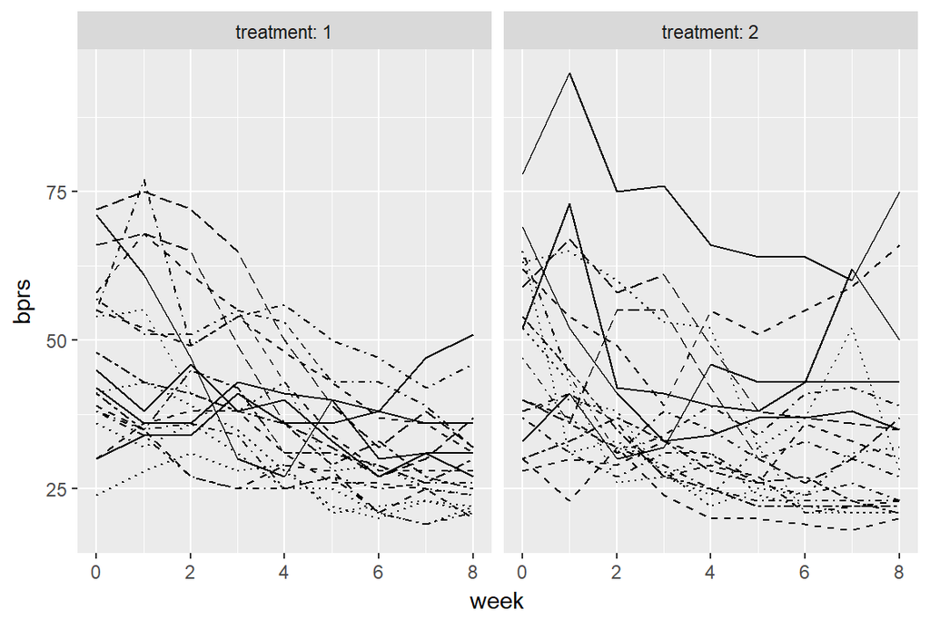

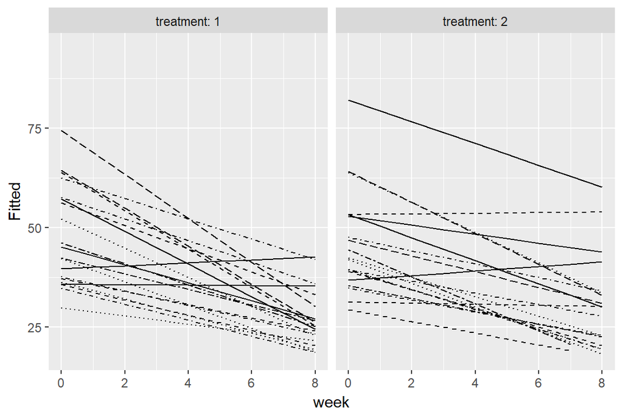

With the Fitted model, it seems a lot more clear to identify some general underlying trends and, importantly, it’s possible to make predictions. As before, the higher tracking individual in treatment 2 clearly stands out. But that’s all for now.

Well, that was quite a lot of work! It’s been an enjoyable course, hopefully you enjoyed the read :-)